# Find Hours

Budget reconciliation, effort only

## The one-line idea

When a new out-of-scope ask lands, **find the hours you already have** before asking for more.

**Net findable** = (∑ Planned + Contingency) − ∑ EAC

- **Under-run slack**: planned effort you are forecast not to spend (planned − EAC, floored at 0)
- **Contingency**: the reserve remaining after existing forecast overruns

Negative net headroom is an existing deficit. The total gap includes that deficit plus any unfunded new ask; review the two separately before a change order.

*Hours / effort only. Synthetic data.*

## Where the numbers come from

| Column | Source of record |
| --- | --- |
| Planned | SOW / budget grid in CTMS |
| Actual to date | Timesheet system |
| % complete, EAC | Your estimate + progress tracker |
| Change order | Contract: lead biostat + PM review, sponsor sign-off, SOW amended |

The tool never invents a number. You transcribe current figures in, so the reconciliation is attributable.

## What to do with a new ask

[figure not shown]

## The live roll-up

850

Planned

513

Spent

831

EAC

40

Contingency

59

Net findable

( 850 + 40 ) − 831 = **59 h** you can redirect before a change order.

## Planned vs forecast

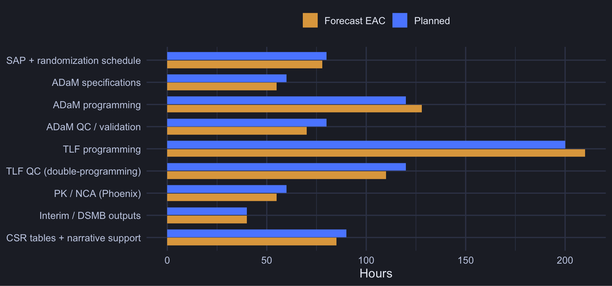

## Ask 45 h, absorbable

Ask 45 h → Absorbable internally

Contingency left: 14 h

Fully covered from what you already hold: no residual, 14 h of reserve still in hand.

## Ask 90 h, change order

Ask 90 h → Change order needed: 31 h

Contingency left: 0 h

Slack and the full reserve are exhausted. The **31 h** residual is genuine new scope: it goes to the change-order process. The tool drafts the hours-only note; pricing is handled downstream by the PM.

## Run it / build it

```r
shiny::runApp("budget_reconciliation/shiny")
# install.packages(c("shiny","bslib","DT","ggplot2"))
```

- **Run**: Run & build the Shiny app, edit an EAC, change the ask, watch net-findable recompute
- **Share**: dashboard · **Skim**: one-pager
- **File**: Excel workbook
- **Build**: build-it walkthrough

*Synthetic data. Hours / effort only. A change order is a named-human, contracted decision.*